# STA 207

Romy Gou, Seoyoung Kim, Zichen Liu, Mario Arce Acosta

2026-03-16

## Libraries

```r
library(tidyverse)
library(dplyr)
library(ggplot2)
library(patchwork)
library(knitr)
library(kableExtra)
library(car)
library(ggalluvial)
library(haven)
library(lme4)
library(lmerTest)
library(performance)
library(webshot2)
library(broom.mixed)
library(stringr)
```

## Background

### Data Source and Experimental Design

The dataset analyzed in this report originates from Project STAR (Student/Teacher Achievement Ratio), a large-scale longitudinal randomized controlled trial conducted in Tennessee public schools between 1985 and 1989. The raw data was accessed via the Harvard Dataverse repository. The primary objective of the experiment was to evaluate the impact of class size on early childhood academic achievement, which was measured annually through standardized math and reading test scores.

Within the participating schools, entering students and their teachers were randomly assigned to one of three classroom environments: small classes (targeted at 13 to 17 students), regular classes (22 to 25 students), and regular classes supplemented with a full-time teacher’s aide. The design intended for students to remain in their assigned class type from kindergarten through the third grade, allowing researchers to observe cumulative educational effects over time.

## Questions of Interest

Motivated by the complexities of nested data structures and the equity imperative highlighted in the historical literature, this report aims to answer the following specific questions of interest:

1. **Main Effect of Class Size:** To what extent does assignment to a small class environment in early primary grades (1st through 3rd) longitudinally impact math achievement scores compared to regular class assignments?
2. **Equity and Interaction Effects:** Does the magnitude of the class-size intervention effect vary significantly across demographic strata? Specifically, is there a statistically significant interaction between class type and student minority status or socio-economic indicators (e.g., free/reduced lunch program eligibility), and does this intervention serve as an equalizing mechanism against Marginalization-Related Diminished Returns?

These questions are of profound interest because they directly bridge classical experimental findings with modern, computationally rigorous multi-level modeling. By answering them, we can provide highly nuanced, statistically sound policy recommendations regarding the targeted allocation of class-size reduction resources.

## Data Cleaning and Preparing

```r
STAR_Students <- read_sav("STAR_Students.sav")
```

```
## Failed to find G1READ_A
## Failed to find G1MATH_A
## Failed to find G2READ_A
## Failed to find G2MATH_A
## Failed to find G3READ_A
## Failed to find G3MATH_A
```

```r
STAR_Students
```

```
## # A tibble: 11,601 × 379
##    stdntid gender  race    birthmonth birthday birthyear FLAGSGK FLAGSG1 FLAGSG2
##      <dbl> <dbl+l> <dbl+l> <dbl+lbl>     <dbl>     <dbl> <dbl+l> <dbl+l> <dbl+l>
##  1   10000 1 [MAL… 1 [WHI… 1 [JANUAR…       22      1979 0 [NO]  1 [YES] 1 [YES]
##  2   10001 1 [MAL… 1 [WHI… 2 [FEBRUA…       20      1980 1 [YES] 0 [NO]  0 [NO]
##  3   10002 2 [FEM… 2 [BLA… 7 [JULY]         21      1979 0 [NO]  0 [NO]  0 [NO]
##  4   10003 1 [MAL… 1 [WHI… 5 [MAY]          28      1980 0 [NO]  1 [YES] 1 [YES]
##  5   10004 2 [FEM… 2 [BLA… 1 [JANUAR…        2      1980 0 [NO]  0 [NO]  1 [YES]
##  6   10005 1 [MAL… 2 [BLA… 1 [JANUAR…        1      1980 0 [NO]  0 [NO]  1 [YES]
##  7   10006 2 [FEM… 2 [BLA… 2 [FEBRUA…        5      1979 0 [NO]  0 [NO]  1 [YES]
##  8   10007 1 [MAL… 2 [BLA… 3 [MARCH]        15      1980 0 [NO]  0 [NO]  0 [NO]
##  9   10008 2 [FEM… 2 [BLA… 4 [ARPIL]        23      1979 0 [NO]  1 [YES] 1 [YES]
## 10   10009 2 [FEM… 2 [BLA… 4 [ARPIL]        24      1980 0 [NO]  0 [NO]  0 [NO]
## # ℹ 11,591 more rows
## # ℹ 370 more variables: FLAGSG3 <dbl+lbl>, flaggk <dbl+lbl>, flagg1 <dbl+lbl>,
## #   flagg2 <dbl+lbl>, flagg3 <dbl+lbl>, flagg4 <dbl+lbl>, flagg5 <dbl+lbl>,
## #   flagg6 <dbl+lbl>, flagg7 <dbl+lbl>, flagg8 <dbl+lbl>, flagprt4 <dbl+lbl>,
## #   flagidn8 <dbl+lbl>, flagprt8 <dbl+lbl>, flagsatact <dbl+lbl>,
## #   flaghscourse <dbl+lbl>, flaghsgraduate <dbl+lbl>, gkclasstype <dbl+lbl>,
## #   g1classtype <dbl+lbl>, g2classtype <dbl+lbl>, g3classtype <dbl+lbl>, …
```

```r
star_first_to_third_grade <- STAR_Students %>%
  select(1:7, starts_with("g1"), starts_with("g2"), starts_with("g3")) %>%
  na.omit(race, g1treadss, g1tmathss, g1tlistss, g2treadss, g2tmathss, g2tlistss, g3treadss, g3tmathss, g3tlistss)
```

### HLM Variable Selection

```r
STAR_long <- star_first_to_third_grade %>%
  pivot_longer(
    cols = matches("^g\\d"),
    names_to = c("grade", ".value"),
    names_pattern = "g(\\d)(.*)"
  ) %>%
  mutate(
    small_class = as.factor(ifelse(classtype==1, 1, 0)),
    minority = as.factor(ifelse(race!=1, 1, 0)),
    classtype = as.factor(classtype),
    grade = as.factor(grade),
    schid = as.factor(schid),
    stdntid = as.factor(stdntid)
  ) %>%
  group_by(stdntid) %>%
  filter(n_distinct(schid, na.rm = TRUE) == 1) %>%
  ungroup()

# To see how many students you have left:
print(paste("Students remaining:", n_distinct(STAR_long$stdntid)))
```

```
## [1] "Students remaining: 2149"
```

### ANOVA Variable Selection

```r
star1 <- STAR_Students %>% dplyr::select(1:7, starts_with("g1")) %>% tidyr::drop_na(race, g1treadss, g1tmathss, g1tlistss)

star1 <- star1 %>% dplyr::select(g1tmathss, # outcome
         g1classtype, # factor
         g1freelunch, race, # student-level(baseline)
         g1schid, g1surban, # school-level
         g1tyears, g1trace, g1thighdegree # teacher-level
         )

library(haven)

star1$race <- as_factor(star1$race) |> as.integer()
star1$race <- ifelse(star1$race == 1, 0, 1)
names(star1)[names(star1) == "race"] <- "minority"


star1$g1freelunch <- factor(
  star1$g1freelunch,
  levels = c(1, 2),
  labels = c("FREE LUNCH", "NON-FREE LUNCH")
)

star1$g1classtype <- factor(
  star1$g1classtype,
  levels = c(1, 2, 3),
  labels = c("SMALL", "REGULAR", "REGULAR+AIDE")
)

star1$g1trace <- factor(
  star1$g1trace,
  levels = c(1, 2),
  labels = c("WHITE", "BLACK")
)

star1$g1thighdegree <- factor(
  star1$g1thighdegree,
  levels = c(1, 2, 3, 4, 5, 6),
  labels = c(
    "ASSOCIATES",
    "BACHELORS",
    "MASTERS",
    "MASTER +",
    "SPECIALIST",
    "DOCTORAL"))

star1$g1surban <- factor(
  star1$g1surban,
  levels = c(1, 2, 3, 4),
  labels = c(
    "INNER CITY",
    "SUBURBAN",
    "RURAL",
    "URBAN"
  )
)

data_clean <-  star1 %>%
  filter(!is.na(g1freelunch))
colSums(is.na(data_clean))
```

```
##     g1tmathss   g1classtype   g1freelunch      minority       g1schid
##             0             0             0             0             0
##      g1surban      g1tyears       g1trace g1thighdegree
##             0             0             0             0
```

```r
data_group_teacher <- data_clean %>%
  group_by(g1schid, g1classtype, g1trace, g1tyears, g1thighdegree) %>%
  summarise(
    Mean = mean(g1tmathss, na.rm = TRUE),
    Min =  min(g1tmathss, na.rm = TRUE),
    Quantile25 = quantile(g1tmathss, 0.25, na.rm = TRUE),
    Median = quantile(g1tmathss, 0.5, na.rm = TRUE),
    Quantile75 = quantile(g1tmathss, 0.75, na.rm = TRUE),
    Max = max(g1tmathss, na.rm = TRUE),
    .groups = "drop"
  )
```

#### Missing Values

```r
colSums(is.na(star1))
```

```
##     g1tmathss   g1classtype   g1freelunch      minority       g1schid
##             0             0           147             0             0
##      g1surban      g1tyears       g1trace g1thighdegree
##             0             0             0             0
```

## Descriptive analysis

Even though STAR intended random assignment, many students did not stay in their assigned class type.

### Noncompliance and Attrition

```r
# drop g1classtype NA
sum(is.na(STAR_Students$g1classtype))
```

```
## [1] 4772
```

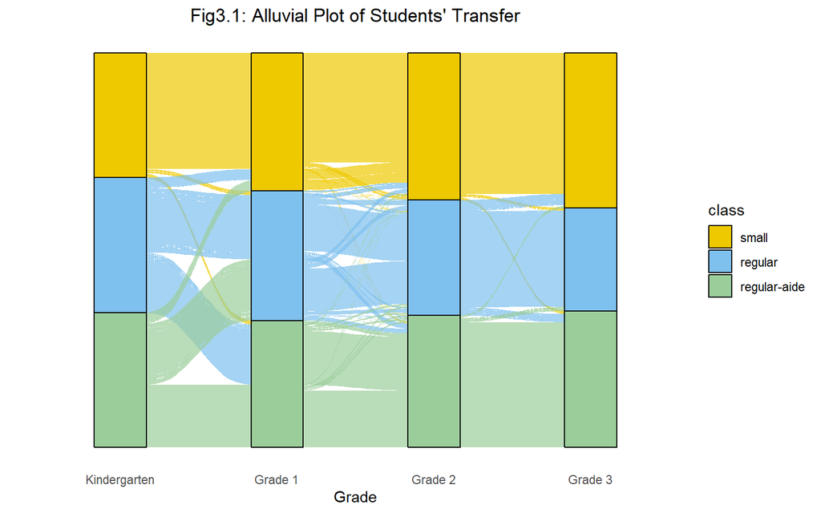

```r
data_alluvium <- subset(STAR_Students, select = c(gkclasstype, g1classtype, g2classtype, g3classtype))

class_levels <- c("small", "regular", "regular-aide")

data_alluvium <- data_alluvium %>%
    mutate(across(everything(),
                  ~factor(as.numeric(.), levels = c(1, 2, 3),
                          labels = class_levels))) %>%
    mutate(across(everything(),
                  ~fct_explicit_na(., na_level = "Unknown"))) %>%
    # Remove any row where at least one grade is Unknown
    filter(if_all(everything(), ~ . != "Unknown"))


class_levels <- c("small", "regular", "regular-aide")
data_alluvium <- data_alluvium %>%
    mutate(across(everything(),
                  ~factor(as.numeric(.), levels = c(1, 2, 3),
                          labels = class_levels))) %>%
    mutate(across(everything(),
                  ~fct_explicit_na(., na_level = "Unknown")))

data_summary <- data_alluvium %>%
    count(gkclasstype, g1classtype, g2classtype, g3classtype, name = "Freq") %>%
    mutate(path_id = row_number())

data_long <- data_summary %>%
    pivot_longer(cols = starts_with("g"), names_to = "grade", values_to = "class")

data_long$grade <- factor(data_long$grade,
            levels = c("gkclasstype", "g1classtype", "g2classtype","g3classtype"),
            labels = c("Kindergarten", "Grade 1", "Grade 2", "Grade 3"))

ggplot(data_long, aes(x = grade, stratum = class, alluvium = path_id, y = Freq, fill = class)) +
    geom_flow(stat = "alluvium", alpha = 0.7) +
    geom_stratum() +
    scale_fill_manual(values = c("gold2", "skyblue2", "darkseagreen3")) +
    theme_minimal() +
    labs(title = "Fig3.1: Alluvial Plot of Students' Transfer", x = "Grade", y = "") +
    theme(legend.position = "right",
          axis.text.x = element_text(hjust = 0.5),
          axis.text.y = element_blank(),
          axis.ticks.y = element_blank(),
          axis.ticks.x = element_blank(),
          panel.grid.major.y = element_blank(),
          panel.grid.minor.y = element_blank(),
          panel.grid.major.x = element_blank(),
          panel.grid.minor.x = element_blank(),
          plot.title = element_text(hjust = 0.5))
```

Drop rows with STAR_Students$g1classtype=NA (4772 rows dropped)

Originally, STAR planned to keep students in the same classroom type from kindergarten through third grade, but that didn’t last. After parents raised concerns, noted in Hanushek (1999), the study was modified so that at the start of first grade, all students in regular‑size classes—whether or not they had an aide—were randomly reassigned to either a regular class with an aide or one without. Students who began in small classes weren’t part of this reshuffling and stayed in small classes for the rest of the study.

Beyond this official change, schools didn’t always follow the assignment rules in practice. Some, especially smaller ones, made informal adjustments once the year began. These weren’t parent-driven; they were practical decisions by administrators or teachers trying to manage real‑world constraints. Schools moved students to balance class sizes, address classroom dynamics, and etc. None of this was part of the experimental protocol, but it still mattered because it introduced nonrandom noncompliance. Finn & Achilles (1999) note that this weakens the clean randomization and can bias causal estimates.

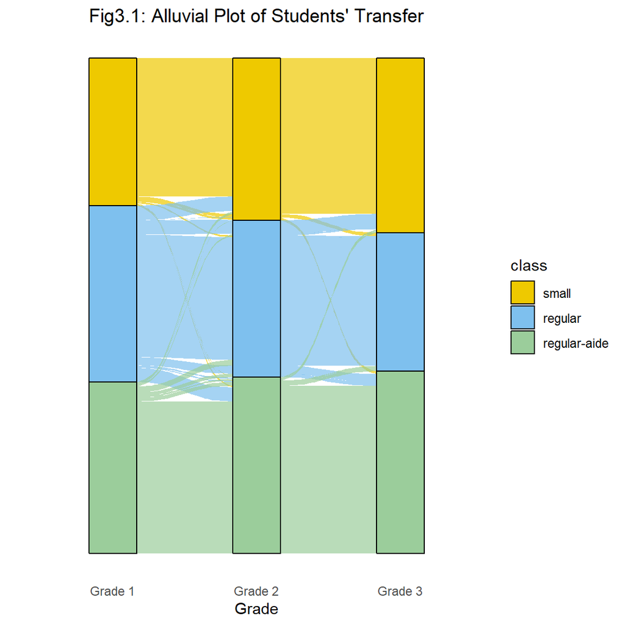

```r
# drop kindergarteners
data_alluvium <- subset(STAR_Students, select = c(g1classtype, g2classtype, g3classtype))

class_levels <- c("small", "regular", "regular-aide")

data_alluvium <- data_alluvium %>%
    mutate(across(everything(),
                  ~factor(as.numeric(.), levels = c(1, 2, 3),
                          labels = class_levels))) %>%
    mutate(across(everything(),
                  ~fct_explicit_na(., na_level = "Unknown"))) %>%
    # Remove any row where at least one grade is Unknown
    filter(if_all(everything(), ~ . != "Unknown"))


class_levels <- c("small", "regular", "regular-aide")
data_alluvium <- data_alluvium %>%
    mutate(across(everything(),
                  ~factor(as.numeric(.), levels = c(1, 2, 3),
                          labels = class_levels))) %>%
    mutate(across(everything(),
                  ~fct_explicit_na(., na_level = "Unknown")))

data_summary <- data_alluvium %>%
    count(g1classtype, g2classtype, g3classtype, name = "Freq") %>%
    mutate(path_id = row_number())

data_long <- data_summary %>%
    pivot_longer(cols = starts_with("g"), names_to = "grade", values_to = "class")

data_long$grade <- factor(data_long$grade,
            levels = c("g1classtype", "g2classtype","g3classtype"),
            labels = c("Grade 1", "Grade 2", "Grade 3"))

ggplot(data_long, aes(x = grade, stratum = class, alluvium = path_id, y = Freq, fill = class)) +
    geom_flow(stat = "alluvium", alpha = 0.7) +
    geom_stratum() +
    scale_fill_manual(values = c("gold2", "skyblue2", "darkseagreen3")) +
    theme_minimal() +
    labs(title = "Fig3.1: Alluvial Plot of Students' Transfer", x = "Grade", y = "") +
    theme(legend.position = "right",
          axis.text.x = element_text(hjust = 0.5),
          axis.text.y = element_blank(),
          axis.ticks.y = element_blank(),
          axis.ticks.x = element_blank(),
          panel.grid.major.y = element_blank(),
          panel.grid.minor.y = element_blank(),
          panel.grid.major.x = element_blank(),
          panel.grid.minor.x = element_blank(),
          plot.title = element_text(hjust = 0.5))
```

### Class Size vs Class Type Density

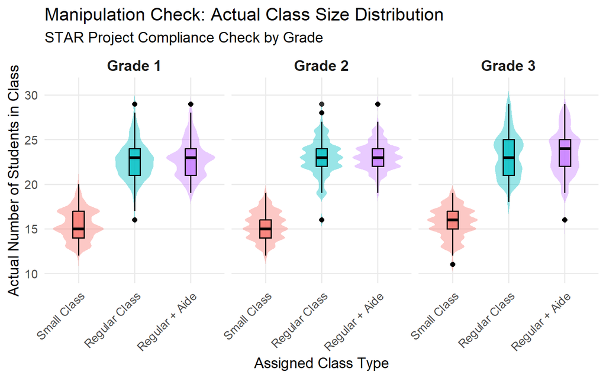

```r
STAR_viz <- STAR_long %>%
  mutate(
    # Swapped 'small_class' for 'classtype' to capture all three assignments
    assigned_type = factor(classtype,
                           levels = c(1, 2, 3), # Standard STAR numeric codes
                           labels = c("Small Class", "Regular Class", "Regular + Aide")),
    grade_label = paste("Grade", grade)
  )

# 2. Create the hybrid Violin + Boxplot
class_density <- ggplot(STAR_viz, aes(x = assigned_type, y = classsize, fill = assigned_type)) +

  # Violin Plot
  geom_violin(alpha = 0.4, color = NA, trim = FALSE) +

  # Boxplot
  # width = 0.2 makes it thin so it fits perfectly inside the "belly" of the violin
  geom_boxplot(width = 0.2, alpha = 0.8, color = "black") +

  # Facet by grade
  facet_wrap(~ grade_label) +

  # Formatting & Aesthetics
  theme_minimal(base_size = 14) +
  labs(title = "Manipulation Check: Actual Class Size Distribution",
       subtitle = "STAR Project Compliance Check by Grade",
       x = "Assigned Class Type",
       y = "Actual Number of Students in Class") +
  theme(legend.position = "none",
        strip.text = element_text(face = "bold", size = 14),
        panel.grid.minor = element_blank()) +

  # The Colorful Part: Added a third color ("#C77CFF" / Purple) for the Aide class
  scale_fill_manual(values = c("Small Class" = "#F8766D",
                               "Regular Class" = "#00BFC4",
                               "Regular + Aide" = "#C77CFF")) +

  # Keeping this here in case you add geom_jitter() back into your plot later!
  scale_color_manual(values = c("Small Class" = "#D95F56",
                                "Regular Class" = "#008B8E",
                                "Regular + Aide" = "#A566D6"))

# Add this to the very bottom of your ggplot code:
class_density <- class_density +
  theme(axis.text.x = element_text(angle = 45, hjust = 1))

class_density
```

```r
ggsave(
  filename = "class_density.png",
  plot     = class_density
  )
```

### Class Type Frequency

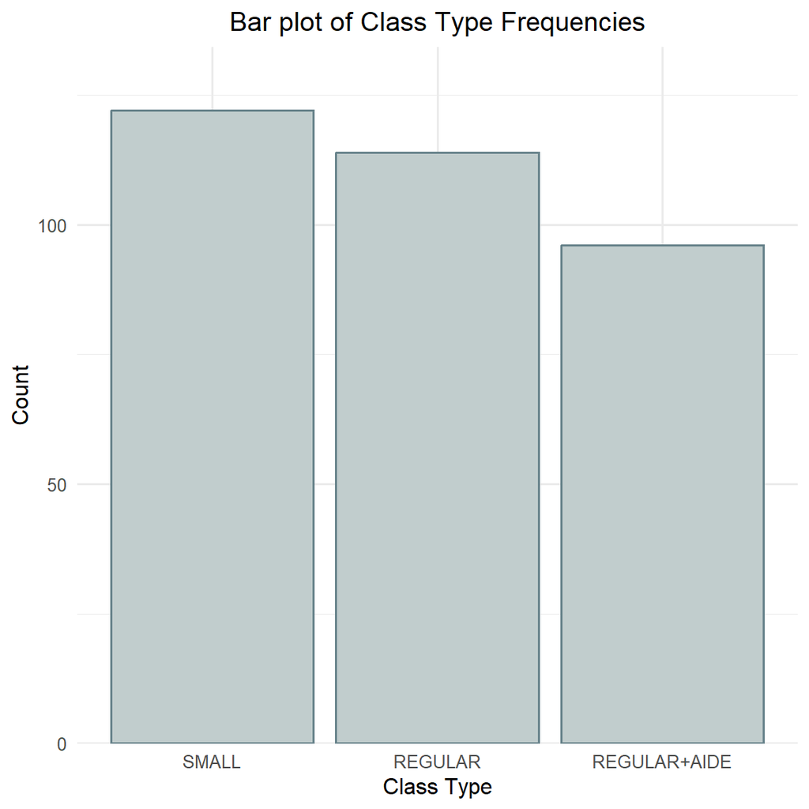

```r
ggplot(data_group_teacher, aes(g1classtype)) +
  geom_histogram(stat = "count", fill = "azure3", color = "lightblue4")+
  labs(x = 'Class Type', y = 'Count', title="Bar plot of Class Type Frequencies") +
    theme_minimal(base_size = 12) +
  scale_y_continuous(expand = expansion(mult = c(0, 0.1))) +
  theme(plot.title = element_text(hjust = 0.5))
```

### (Student-level) Normality of Outcome Variable

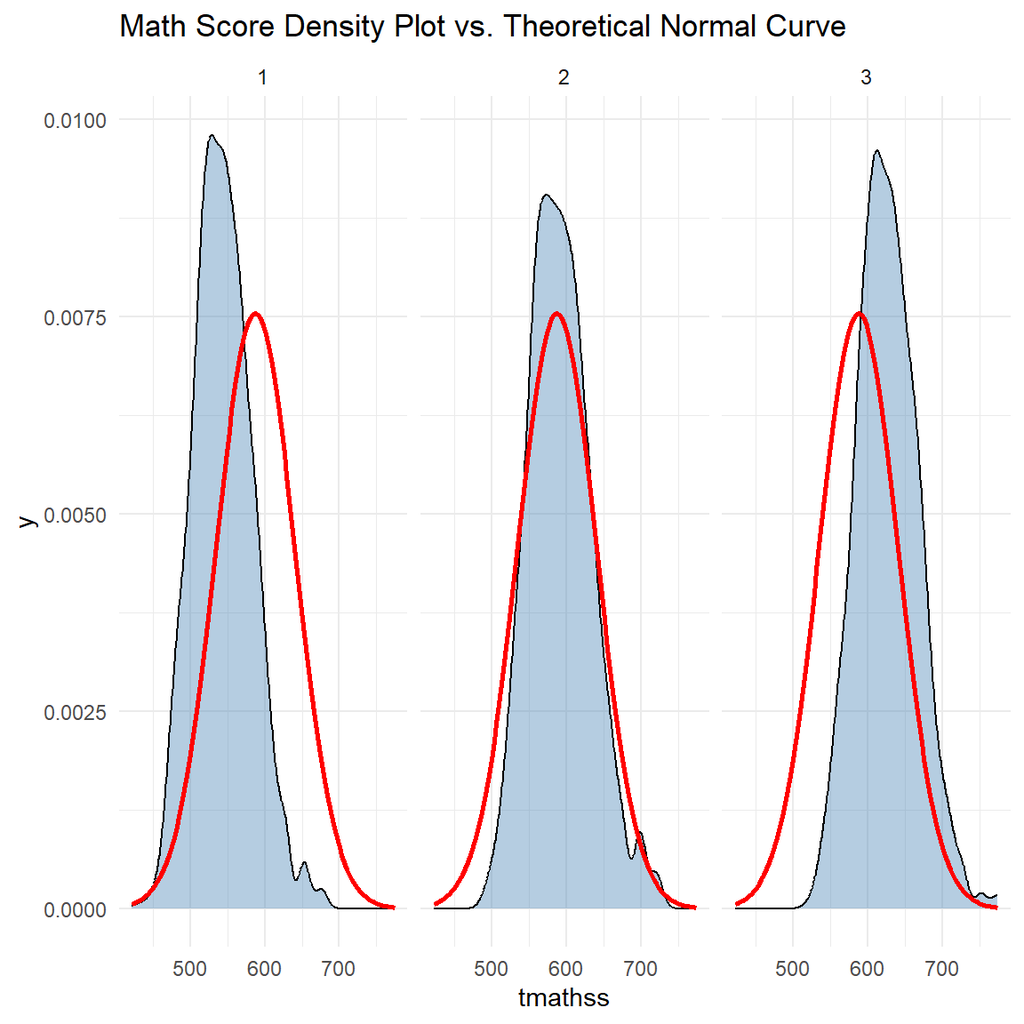

```r
math_density <- ggplot(STAR_long, aes(x = tmathss)) +
  geom_density(fill = "steelblue", alpha = 0.4) +
  # Add a theoretical normal curve for comparison
  stat_function(fun = dnorm,
                args = list(mean = mean(STAR_long$tmathss, na.rm = TRUE),
                            sd = sd(STAR_long$tmathss, na.rm = TRUE)),
                color = "red", size = 1) +
  facet_wrap(~ grade) +
  theme_minimal() +
  labs(title = "Math Score Density Plot vs. Theoretical Normal Curve")
math_density
```

### (Class-level) Normality of Outcome Variable

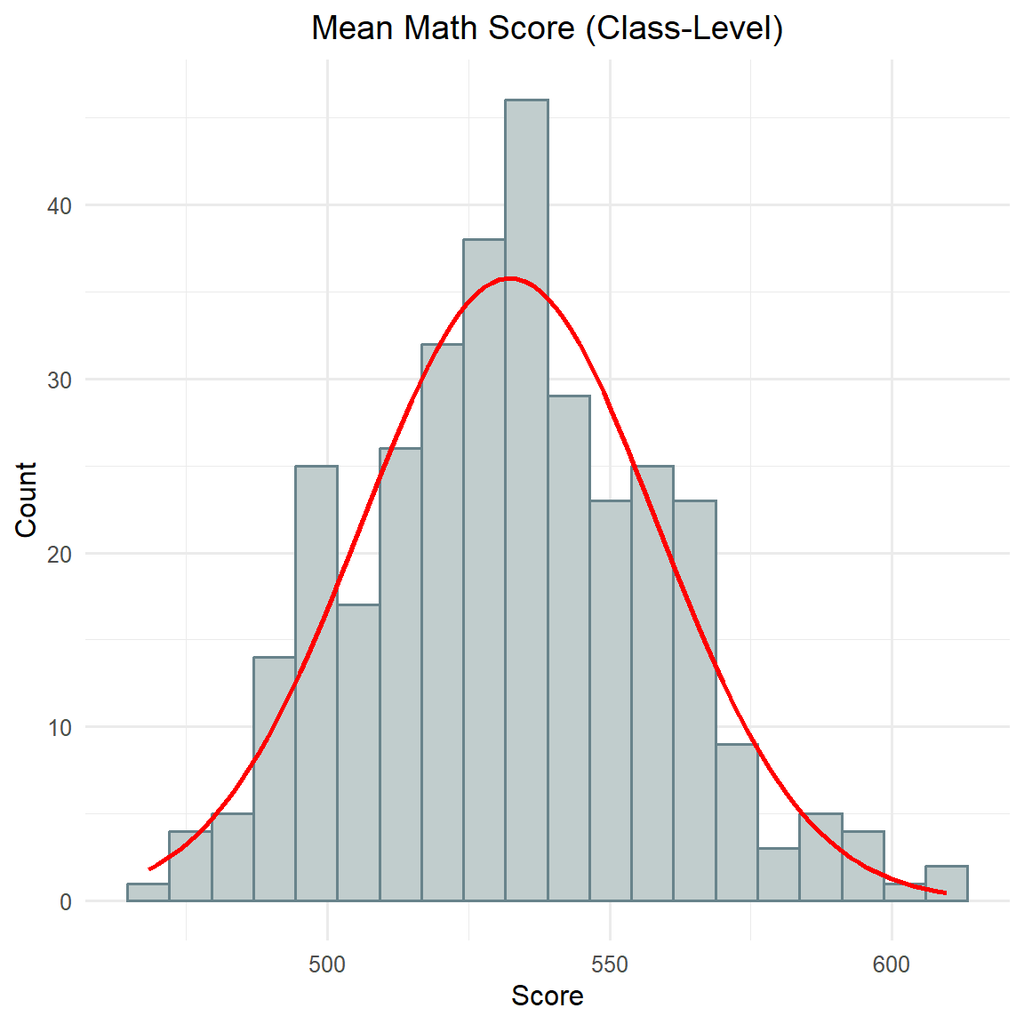

```r
# mean score
ggplot(data_group_teacher, aes(x = Mean)) +
  geom_histogram(aes(y = ..count..),
                 fill = "azure3", color = "lightblue4", bins = 20) +
  stat_function(
    fun = function(x) {
      dnorm(x,
            mean = mean(data_group_teacher$Mean, na.rm = TRUE),
            sd = sd(data_group_teacher$Mean, na.rm = TRUE)
      ) * nrow(data_group_teacher) * diff(range(data_group_teacher$Mean)) / 20
    },
    color = "red", linewidth = 1
  ) +
  labs(x = "Score", y = "Count", title = "Mean Math Score (Class-Level)") +
  theme_minimal(base_size = 12) +
  theme(plot.title = element_text(hjust = 0.5))
```

## Inferential analysis

### ANOVA

```r
data_anova <- data_group_teacher %>%
  dplyr::select(1:7,10)

fit <- aov(Mean~g1classtype+as.factor(g1schid),data_group_teacher)
model_coeff <- fit$coefficients
```

#### Results: Main Effects

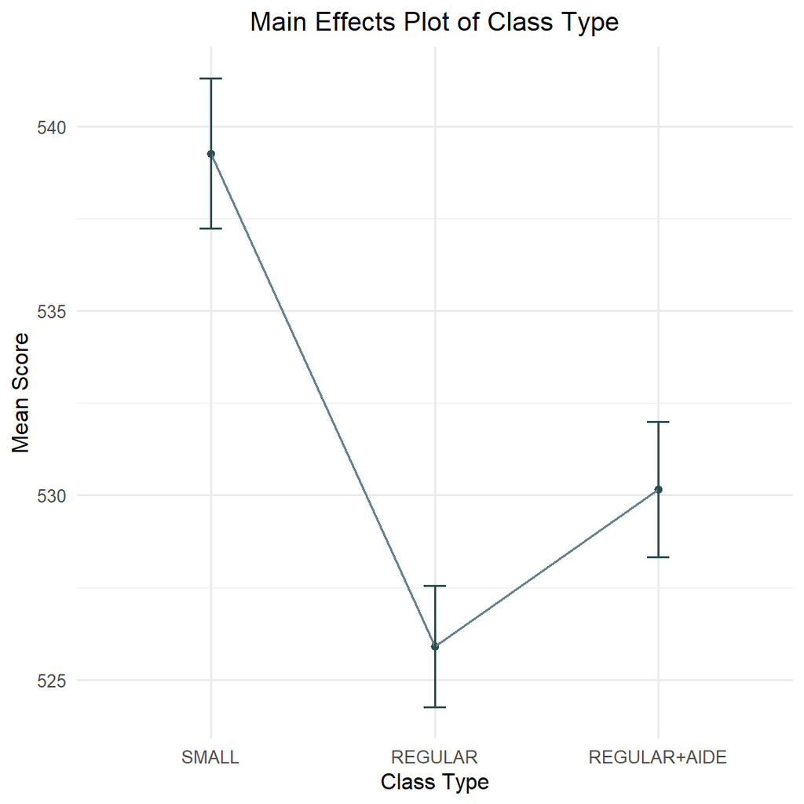

```r
data_maineffct_star <- star1 %>%
  group_by(g1classtype) %>%
 summarize(
    Mean = mean(g1tmathss),
    SE = sd(g1tmathss) / sqrt(n()),
    LowerCI = Mean - qt(0.975, df = n() - 1) * SE,
    UpperCI = Mean + qt(0.975, df = n() - 1) * SE)


ggplot(data_maineffct_star, aes(x = g1classtype, y = Mean, group = 1)) +
  geom_point(color = "darkslategray") +
  geom_line(color = "lightblue4") +
  geom_errorbar(aes(ymin = LowerCI, ymax = UpperCI), width = 0.1,color = "darkslategray") +
  labs(title = "Main Effects Plot of Class Type",
       x = "Class Type",
       y = "Mean Score") +
    theme_minimal(base_size = 12) +
  theme(plot.title = element_text(hjust = 0.5))
```

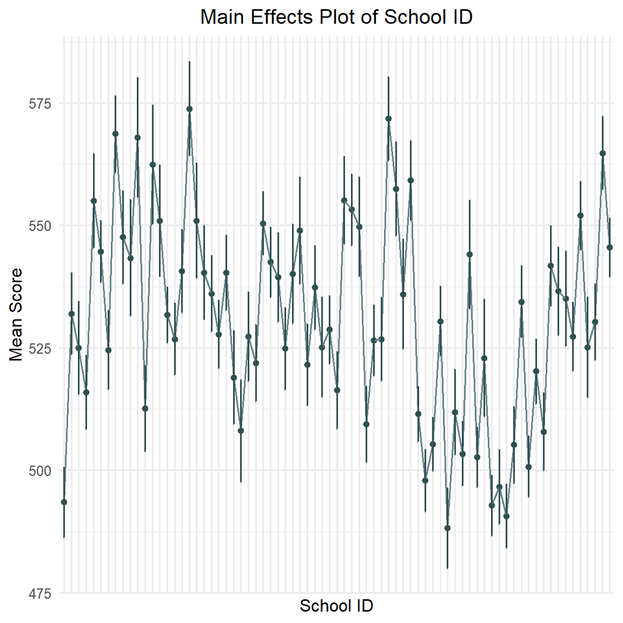

```r
data_maineffct_school <- star1 %>%
  group_by(g1schid) %>%
 summarize(
    Mean = mean(g1tmathss),
    SE = sd(g1tmathss) / sqrt(n()),
    LowerCI = Mean - qt(0.975, df = n() - 1) * SE,
    UpperCI = Mean + qt(0.975, df = n() - 1) * SE)


ggplot(data_maineffct_school, aes(x = as.factor(g1schid), y = Mean, group = 1)) +
  geom_point(color = "darkslategray") +
  geom_line(color = "lightblue4") +
  geom_errorbar(aes(ymin = LowerCI, ymax = UpperCI), width = 0.1,color = "darkslategray") +
  labs(title = "Main Effects Plot of School ID",
       x = "School ID",
       y = "Mean Score") +
    theme_minimal(base_size = 12) +
  theme(plot.title = element_text(hjust = 0.5)) +
  theme(axis.text.x = element_blank(), axis.ticks.x = element_blank())
```

From the plot of Class Type main effects, the group means are clearly separated: - Small classes have the highest mean math scores - Regular + aide are in the middle - Regular classes have the lowest mean scores The differences are not only visible but substantively meaningful (≈10–15 points). The mean 1st‑grade scaled math score differs significantly across class‑size conditions. Students in small classes score higher on average than those in regular or regular‑with‑aide classes.

School ID Main Effects Plot Huge variation across schools (scores ranging ~490–580) School‑level differences are much larger than class‑type differences school is a major source of heterogeneity, but class size still has a consistent effect across schools.

There is a statistically significant association between class size and 1st‑grade scaled math scores. Students assigned to small classes score higher on average than those in regular or regular‑with‑aide classes. This effect remains visible even after accounting for substantial differences across schools.

#### Model Fitting

##### Minority_rate: proportion minority in each classroom (school-level)

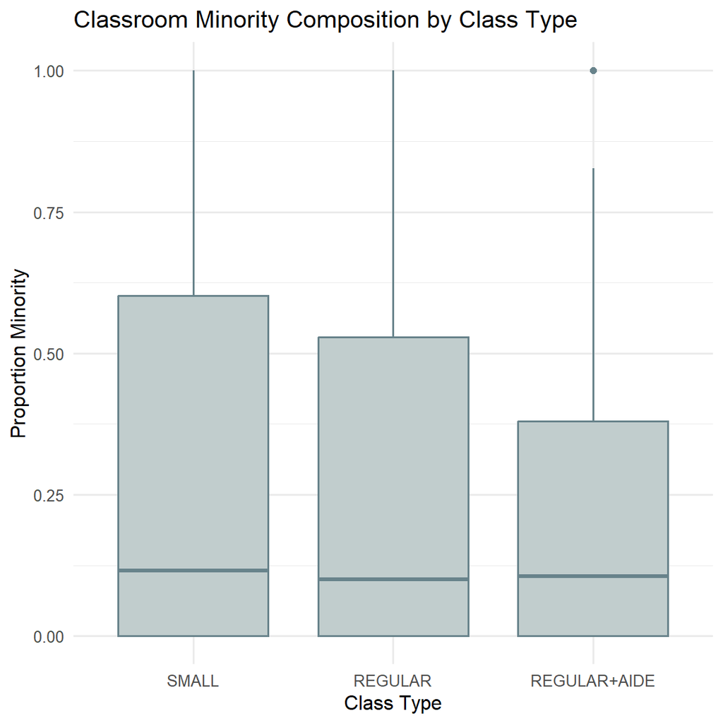

```r
data_group_minority <- data_clean %>%
  group_by(g1schid, g1classtype) %>%
  summarise(
    MinorityRate = mean(minority, na.rm = TRUE),
    Mean = mean(g1tmathss, na.rm = TRUE),
    .groups = "drop"
  )

ggplot(data_group_minority, aes(x = as.factor(g1classtype), y = MinorityRate)) +
  geom_boxplot(fill = "azure3", color = "lightblue4") +
    theme_minimal(base_size = 12) +
  labs(title = "Classroom Minority Composition by Class Type",
       x = "Class Type", y = "Proportion Minority")
```

Class types are not perfectly balanced in terms of minority composition. Even though STAR was randomized, real‑world implementation (attrition, reassignment, school constraints) created demographic imbalance across class types.

```r
fit2 <- aov(Mean ~ g1classtype *MinorityRate + as.factor(g1schid),
            data = data_group_minority)
```

#### F-test

```r
library(car)
Anova(fit2, type = 2)
```

```
## Anova Table (Type II tests)
##
## Response: Mean
##                          Sum Sq  Df F value    Pr(>F)
## g1classtype                6477   2 16.0001 5.520e-07 ***
## MinorityRate                395   1  1.9540    0.1644
## as.factor(g1schid)        70342  74  4.6966 1.924e-15 ***
## g1classtype:MinorityRate     46   2  0.1127    0.8935
## Residuals                 28335 140
## ---
## Signif. codes:  0 '***' 0.001 '**' 0.01 '*' 0.05 '.' 0.1 ' ' 1
```

```r
Anova(lm(Mean ~ g1classtype *MinorityRate + as.factor(g1schid),
            data = data_group_minority), type=2)
```

```
## Anova Table (Type II tests)
##
## Response: Mean
##                          Sum Sq  Df F value    Pr(>F)
## g1classtype                6477   2 16.0001 5.520e-07 ***
## MinorityRate                395   1  1.9540    0.1644
## as.factor(g1schid)        70342  74  4.6966 1.924e-15 ***
## g1classtype:MinorityRate     46   2  0.1127    0.8935
## Residuals                 28335 140
## ---
## Signif. codes:  0 '***' 0.001 '**' 0.01 '*' 0.05 '.' 0.1 ' ' 1
```

```r
library(emmeans)
emmeans(fit2, ~ g1classtype)
```

```
##  g1classtype  emmean   SE  df lower.CL upper.CL
##  SMALL           540 1.66 140      537      543
##  REGULAR         528 1.68 140      525      531
##  REGULAR+AIDE    529 1.74 140      525      532
##
## Results are averaged over the levels of: g1schid
## Confidence level used: 0.95
```

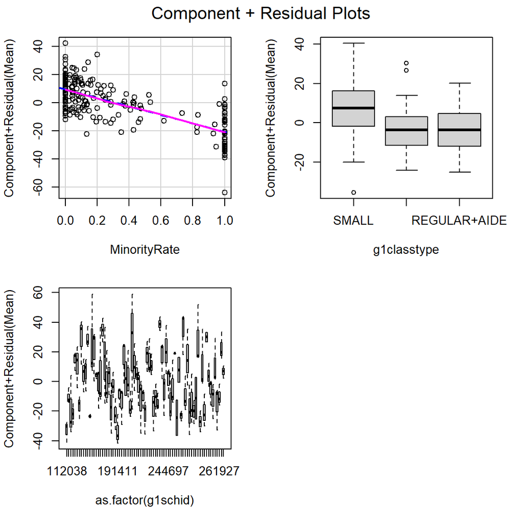

```r
library(car)
crPlots(lm(Mean ~ MinorityRate + g1classtype + as.factor(g1schid),
           data = data_group_minority))
```

#### Assumptions

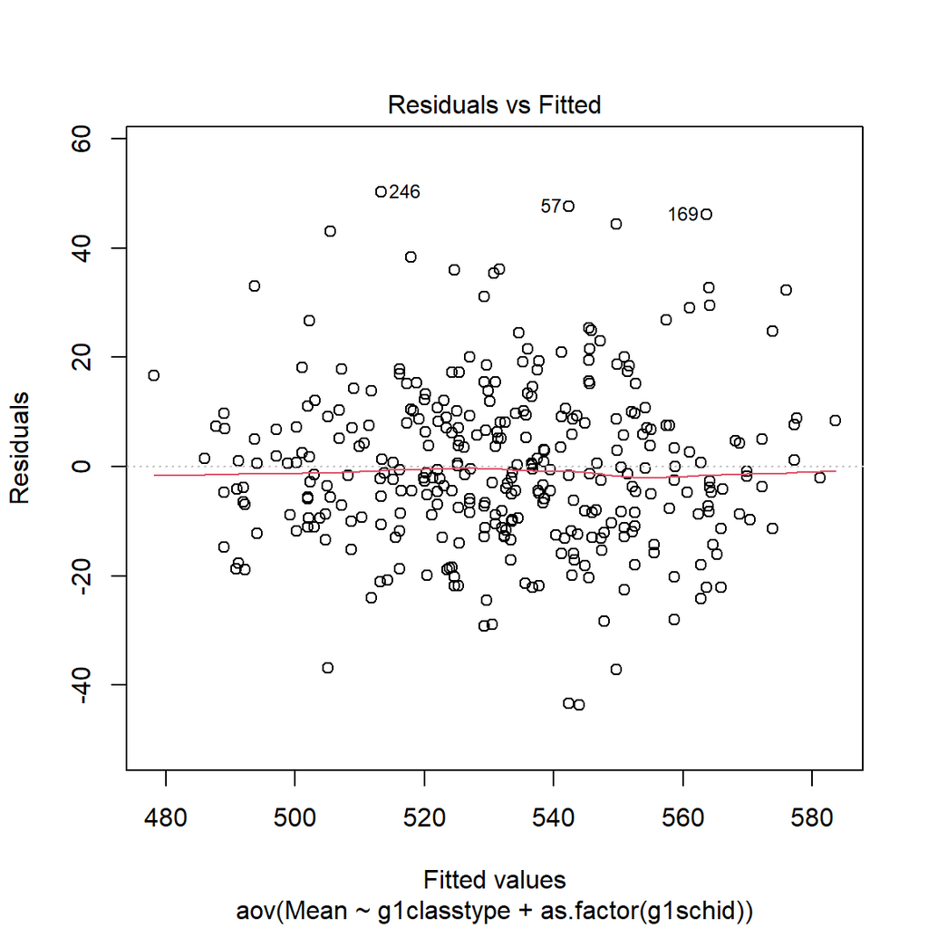

```r
plot(fit, which = 1)   # residuals vs fitted
```

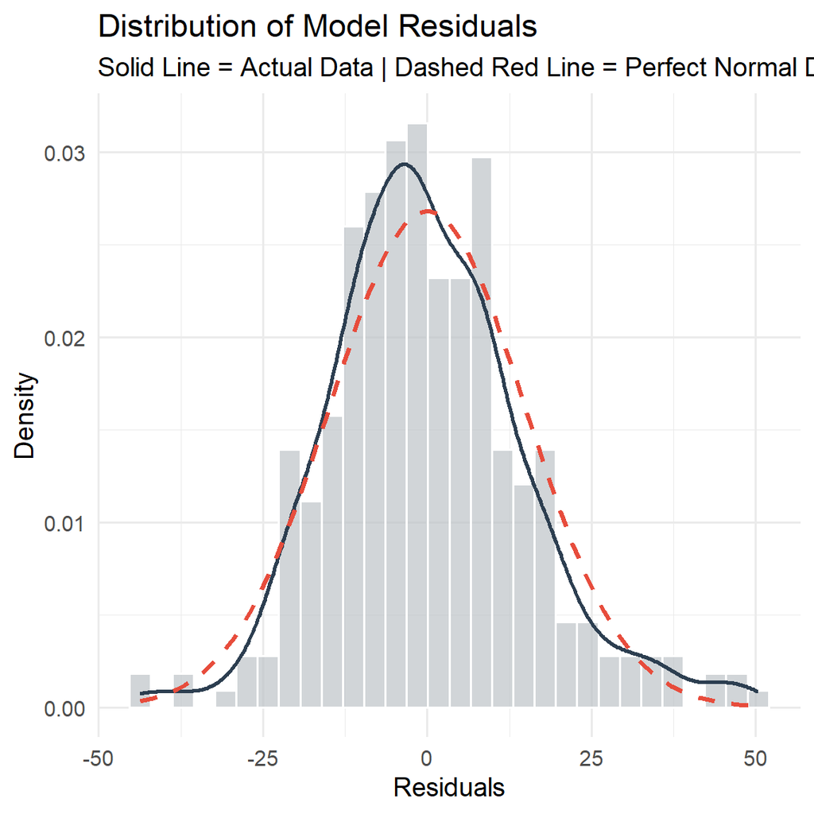

```r
# 1. Extract the residuals from your model
model_res <- data.frame(res = residuals(fit))

# 2. Plot the actual distribution vs. a theoretical perfect normal curve
ggplot(model_res, aes(x = res)) +
  # The actual data: Histogram
  geom_histogram(aes(y = after_stat(density)), bins = 30,
                 fill = "#BDC3C7", color = "white", alpha = 0.7) +

  # The actual data: Smoothed density curve
  geom_density(color = "#2C3E50", linewidth = 1) +

  # The theoretical benchmark: Perfect normal distribution overlay
  stat_function(
    fun = dnorm,
    args = list(mean = mean(model_res$res, na.rm = TRUE),
                sd = sd(model_res$res, na.rm = TRUE)),
    color = "#E74C3C",
    linewidth = 1.2,
    linetype = "dashed"
  ) +

  # Clean formatting
  theme_minimal(base_size = 14) +
  labs(
    title = "Distribution of Model Residuals",
    subtitle = "Solid Line = Actual Data | Dashed Red Line = Perfect Normal Distribution",
    x = "Residuals",
    y = "Density"
  )
```

```r
library(car)
leveneTest(Mean ~ g1classtype, data = data_group_teacher)
```

```
## Levene's Test for Homogeneity of Variance (center = median)
##        Df F value Pr(>F)
## group   2  0.7798 0.4593
##       329
```

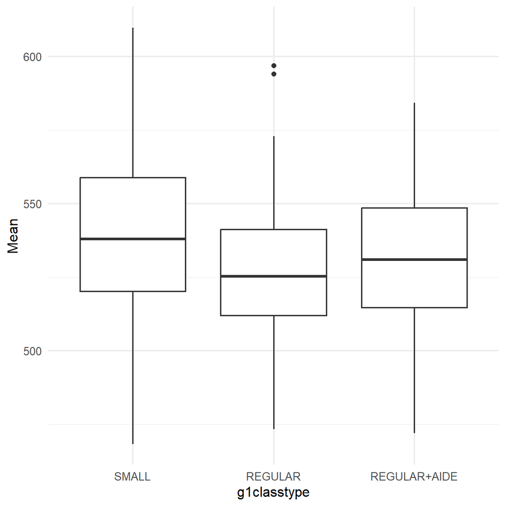

```r
ggplot(data_group_teacher, aes(x = g1classtype, y = Mean)) +
  geom_boxplot() +
  theme_minimal(base_size = 12)
```

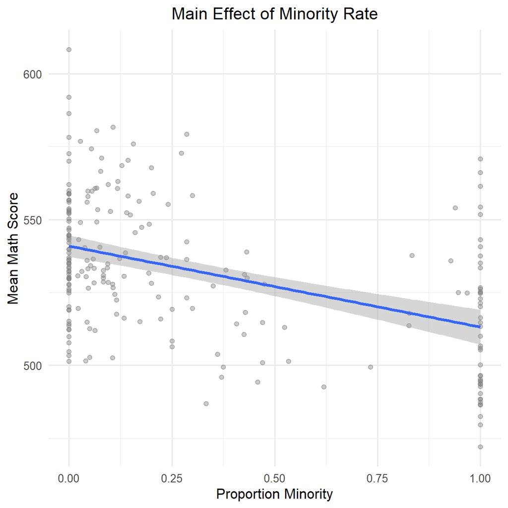

```r
data_group_minority <- data_group_minority %>%
  mutate(MinorityBin = cut(MinorityRate,
                           breaks = seq(0, 1, by = 0.2),
                           include.lowest = TRUE))

ggplot(data_group_minority, aes(x = MinorityRate, y = Mean)) +
  geom_point(alpha = 0.4, color = "gray50") +
  geom_smooth(method = "lm", se = TRUE) +
  labs(
    title = "Main Effect of Minority Rate",
    x = "Proportion Minority",
    y = "Mean Math Score"
  ) +
  theme_minimal(base_size = 12) +
  theme(plot.title = element_text(hjust = 0.5))
```

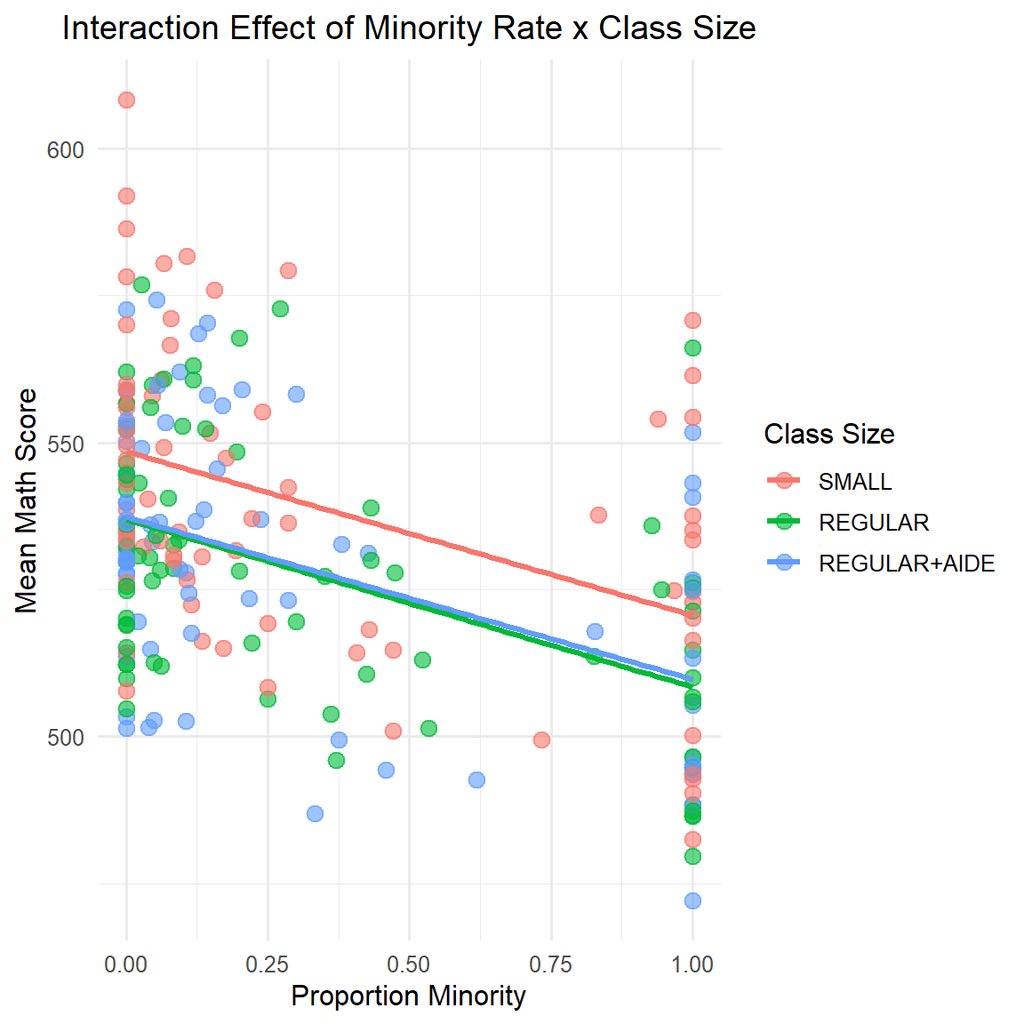

```r
ggplot(data_group_minority,
       aes(x = MinorityRate, y = Mean, color = g1classtype)) +
    geom_point(alpha = 0.6, size = 3) +
    geom_smooth(method = "lm", se = FALSE) +
    labs(
        title = "Interaction Effect of Minority Rate x Class Size",
        x = "Proportion Minority",
        y = "Mean Math Score",
        color = "Class Size"
    ) +
    theme_minimal(base_size = 12) +
    theme(plot.title = element_text(hjust = 0.5))
```

Scores are highest when MinorityRate is low.

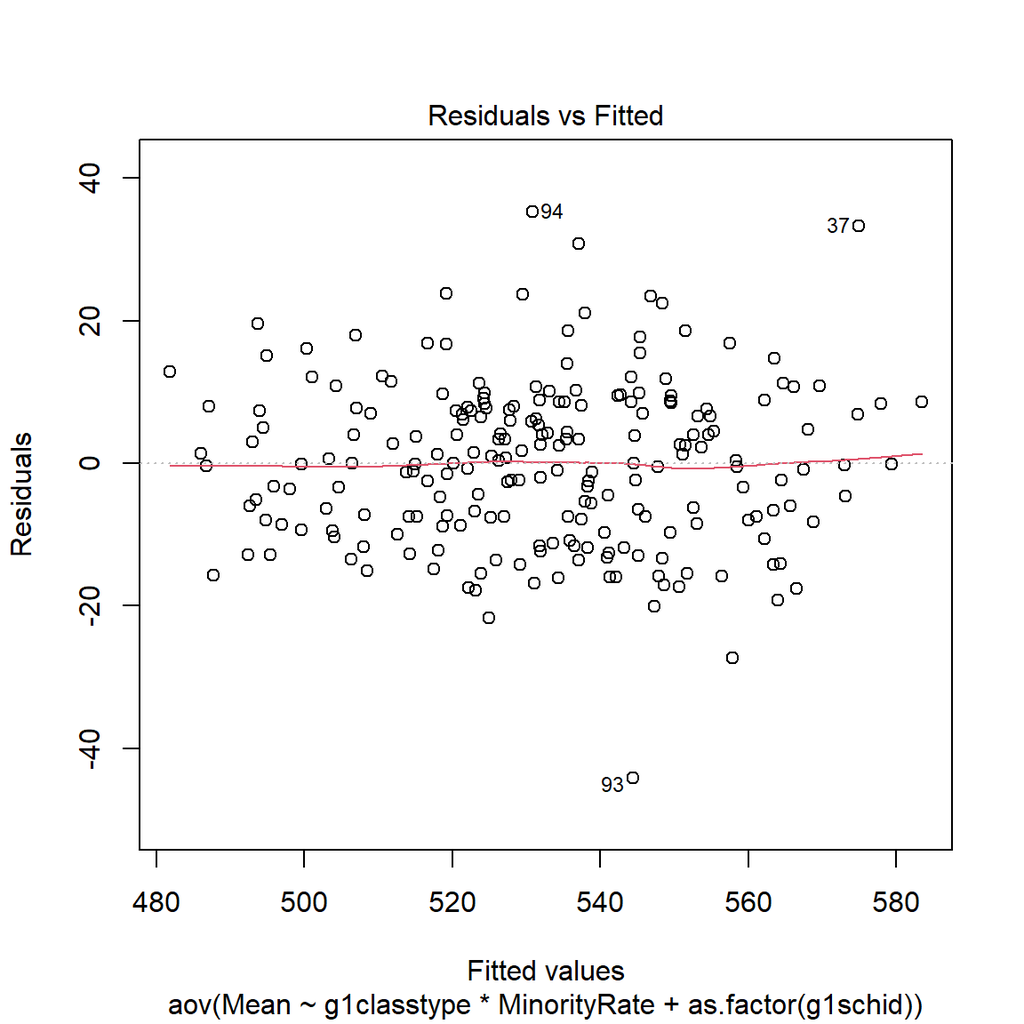

```r
plot(fit2, which = 1)   # residuals vs fitted
```

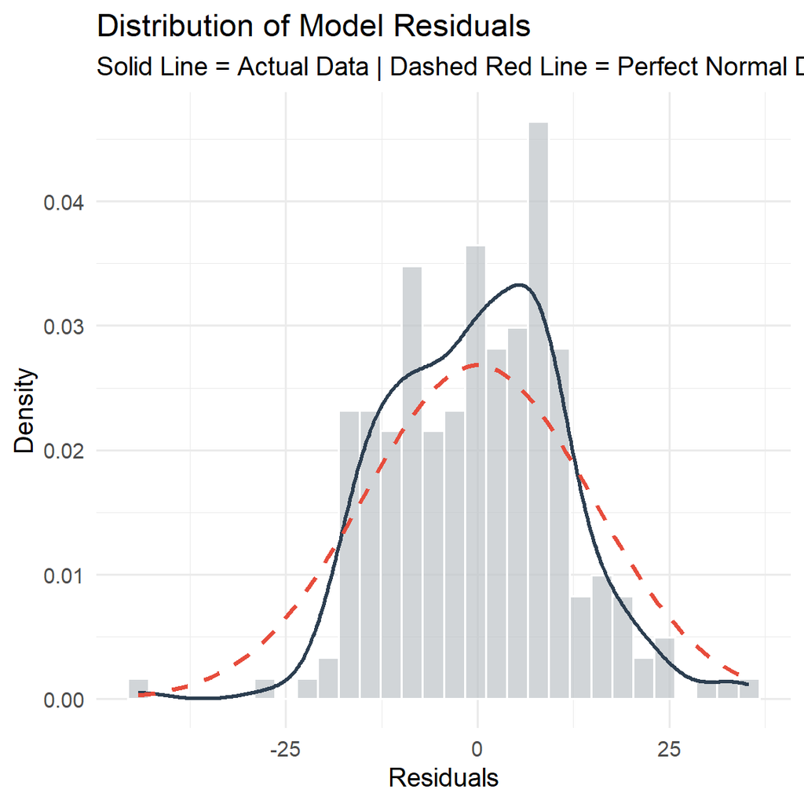

```r
# 1. Extract the residuals from your model
model_res_2 <- data.frame(res = residuals(fit2))

# 2. Plot the actual distribution vs. a theoretical perfect normal curve
ggplot(model_res_2, aes(x = res)) +
  # The actual data: Histogram
  geom_histogram(aes(y = after_stat(density)), bins = 30,
                 fill = "#BDC3C7", color = "white", alpha = 0.7) +

  # The actual data: Smoothed density curve
  geom_density(color = "#2C3E50", linewidth = 1) +

  # The theoretical benchmark: Perfect normal distribution overlay
  stat_function(
    fun = dnorm,
    args = list(mean = mean(model_res$res, na.rm = TRUE),
                sd = sd(model_res$res, na.rm = TRUE)),
    color = "#E74C3C",
    linewidth = 1.2,
    linetype = "dashed"
  ) +

  # Clean formatting
  theme_minimal(base_size = 14) +
  labs(
    title = "Distribution of Model Residuals",
    subtitle = "Solid Line = Actual Data | Dashed Red Line = Perfect Normal Distribution",
    x = "Residuals",
    y = "Density"
  )
```